# Practicum Activity: Gene Expression Challenge

Practicum 2 - TOTD 2026/27

Oriol Arasa - Group C, oriol.arasa@estudiants.urv.cat Izan Flores - Group C, izan.flores@estudiants.urv.cat Andreu Jordà - Group C, andreu.jorda@estudiants.urv.cat Jordi Vivas - Group C, jordi.vivas@estudiants.urv.cat Mireia Olivar - Group C, mireia.olivar@estudiants.urv.cat

2026-11-15

# 1. Data Analysis

Read through Wang et al. (2005) and breastCancerVDX package documentation to write a brief summary of vdx dataset. What information does this dataset enclose? Which kind of data does it contains?. Summarize the biological background and the assay leading to such dataset. Describe in your own words the technology used [2/10]

```r
#List all the slots in this object
slotNames(vdx)
```

```
## [1] "experimentData"    "assayData"         "phenoData"
## [4] "featureData"       "annotation"        "protocolData"
## [7] ".__classVersion__"
```

```r
summary(vdx)
```

```
##        Length         Class          Mode
##             1 ExpressionSet            S4
```

```r
vdx
```

```
## ExpressionSet (storageMode: lockedEnvironment)
## assayData: 22283 features, 344 samples
##   element names: exprs
## protocolData: none
## phenoData
##   sampleNames: VDX_3 VDX_5 ... VDX_2038 (344 total)
##   varLabels: samplename dataset ... e.os (21 total)
##   varMetadata: labelDescription
## featureData
##   featureNames: 1007_s_at 1053_at ... AFFX-TrpnX-M_at (22283 total)
##   fvarLabels: probe Gene.title ... GO.Component.1 (22 total)
##   fvarMetadata: labelDescription
## experimentData: use 'experimentData(object)'
##   pubMedIds: 17420468
## Annotation: hgu133a
```

```r
experimentData(vdx)
```

```
## Experiment data
##   Experimenter name: VDX
##   Laboratory: Veridex LLC, a Johnson & Johnson Company, San Diego, CA, USA. Department of Radiaton and Cellular Oncology, Center for Molecular Oncology, and Ludwig Center for Metastasis Research, University of Chicago, Chicago, IL, USA
##   Contact information: Dr John Foekens, Erasmus MC Josephine Nefkens Institute, Netherlands: <j.foekens@erasmusmc.nl>, Joan Massague,  <j-massagie@ski.mskcc.org>
##   Title: Gene-expression profiles to predict distant metastasis of kymph-node-negative primary breast cancer. Lung metastasis genes coule breast tumor size and metastatic spread.
##   URL: GEO accession number: GSE2034 & GSE5327 <http://www.ncbi.nlm.nih.gov/geo/query/acc.cgi?acc=GSE2034>, <http://www.ncbi.nlm.nih.gov/geo/query/acc.cgi?acc=GSE5327>
##   PMIDs: 17420468
##
##   Abstract: A 235 word abstract is available. Use 'abstract' method.
```

```r
# Gene expression matrix
eValues <- exprs(vdx)
dim(eValues)
```

```
## [1] 22283   344
```

```r
as_tibble(eValues[, 1:5], rownames = "Probe")
```

```
## # A tibble: 22,283 × 6
##    Probe     VDX_3 VDX_5 VDX_6 VDX_7 VDX_8
##    <chr>     <dbl> <dbl> <dbl> <dbl> <dbl>
##  1 1007_s_at 12.0  11.8  11.8  11.5  12.4
##  2 1053_at    7.90  7.89  7.95  7.48  7.71
##  3 117_at     8.26  7.05  8.23  8.38  8.60
##  4 121_at    11.0  10.7  10.9  10.8  10.2
##  5 1255_g_at  6.65  5.45  6.46  6.15  6.60
##  6 1294_at    9.41  9.59  9.42  9.46  9.20
##  7 1316_at    7.30  7.64  7.07  8.12  7.79
##  8 1320_at    4.39  5.07  4.66  6.40  3.69
##  9 1405_i_at  9.26 10.0   9.35 11.5   6.97
## 10 1431_at    6.57  6.23  6.26  5.95  6.96
## # ℹ 22,273 more rows
```

```r
# Clinical and pathological information
pheno <- pData(vdx)
dim(pheno)
```

```
## [1] 344  21
```

```r
pheno |>
  slice_head(n = 10) |>
  select(1:5)
```

```
##        samplename dataset series id        filename
## VDX_3       VDX_3     VDX    VDX  3 GSM36793.CEL.gz
## VDX_5       VDX_5     VDX    VDX  5 GSM36796.CEL.gz
## VDX_6       VDX_6     VDX    VDX  6 GSM36797.CEL.gz
## VDX_7       VDX_7     VDX    VDX  7 GSM36798.CEL.gz
## VDX_8       VDX_8     VDX    VDX  8 GSM36800.CEL.gz
## VDX_9       VDX_9     VDX    VDX  9 GSM36801.CEL.gz
## VDX_11     VDX_11     VDX    VDX 11 GSM36834.CEL.gz
## VDX_14     VDX_14     VDX    VDX 14 GSM36835.CEL.gz
## VDX_15     VDX_15     VDX    VDX 15 GSM36836.CEL.gz
## VDX_17     VDX_17     VDX    VDX 17 GSM36837.CEL.gz
```

```r
# Information about probes and genes
features <- fData(vdx)
dim(features)
```

```
## [1] 22283    22
```

```r
# Probe sets associated with BRCA1
features |>
filter(Gene.symbol == "BRCA1") |>
rownames()
```

```
## [1] "204531_s_at" "211851_x_at"
```

The vdx dataset from the breastCancerVDX package contains gene-expression and clinical data from 344 primary breast-tumour samples. It includes the expression of 22,283 probe sets, together with information such as age, tumour grade, tumour size, lymph-node status, oestrogen receptor status and patient follow-up.

The samples were analysed using Affymetrix Human Genome U133A microarrays. RNA was extracted from frozen tumours, labelled and hybridised to DNA probes on the microarray. The fluorescence intensity measured by the scanner was used to estimate gene expression: a higher signal indicates a higher abundance of the corresponding transcript.

The main objective of Wang et al. (2005) was to identify gene-expression patterns related to the risk of distant metastasis in breast cancer. The study produced a 76-gene prognostic signature, divided into genes for ER-positive and ER-negative tumours.

# 2. Comparison based on oestrogen reception

Compare gene expression values between patients testing for positive or negative oestrogen receptors (ER). Hint: genefilter package has rowttests function which is very convenient to perform a simple one-variable at a time two-sample t-test for all genes in this study and derive a results table.[2/10]

```r
# Convert ER status into a factor
er_status <- factor(pheno$er, levels = c(0, 1),
                    labels = c("ER negative", "ER positive"))

# Perform a two-sample t-test for every probe set
ttest_results <- rowttests(eValues, er_status)

# Create and order the results table
results_ER <- data.frame(Probe = rownames(eValues),ttest_results) |>
  arrange(p.value)

# Add gene symbols
results_ER$Gene.symbol <- features[results_ER$Probe, "Gene.symbol"]

# Display the 10 most significant results
results_ER |>
  select(Probe, Gene.symbol, statistic, dm, p.value) |>
  slice_head(n = 10)
```

```
##                   Probe Gene.symbol statistic        dm      p.value
## 205225_at     205225_at        ESR1 -22.58420 -3.762901 9.004544e-70
## 209603_at     209603_at       GATA3 -18.89942 -3.052348 4.700701e-55
## 209604_s_at 209604_s_at       GATA3 -17.53072 -2.431309 1.523875e-49
## 212956_at     212956_at      TBC1D9 -17.42552 -2.157435 4.037559e-49
## 202088_at     202088_at     SLC39A6 -17.25845 -1.719680 1.895888e-48
## 212496_s_at 212496_s_at       KDM4B -16.82538 -1.459843 1.039846e-46
## 215867_x_at 215867_x_at        CA12 -16.72718 -2.246120 2.575366e-46
## 209602_s_at 209602_s_at       GATA3 -16.35749 -2.921505 7.790349e-45
## 212195_at     212195_at       IL6ST -16.29718 -1.381778 1.357537e-44
## 218195_at     218195_at    C6orf211 -16.22711 -1.738740 2.587515e-44
```

A two-sample t-test was performed for each of the 22,283 probe sets to compare gene expression between ER-positive and ER-negative tumours. The results were ordered by p-value, so the first rows correspond to the genes showing the strongest differences between both groups. A positive or negative dm value indicates the direction of the expression difference between the two ER groups.

# 3. T-test and p-value histogram

From the t-test above, plot a p-value histogram and comment on it (Hint). Do you think that gene expression is different according to ER?. Compute adjusted FDR p-adjusted values. What does this correction account for? Why is it important to apply it here? [2/10]

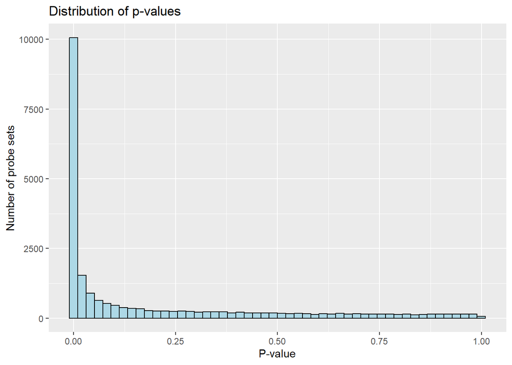

```r
# Histogram of raw p-values
ggplot(results_ER, aes(x = p.value)) +
  geom_histogram(bins = 50, color = "black", fill = "lightblue") +
  labs(
    title = "Distribution of p-values",
    x = "P-value",
    y = "Number of probe sets"
  )
```

```r
# Adjust p-values using the Benjamini-Hochberg FDR method to reduce the false positive
results_ER$p.adjusted <- p.adjust(
  results_ER$p.value,
  method = "BH"
)

# Number of significant probe sets
sum(results_ER$p.value < 0.05)
```

```
## [1] 12460
```

```r
sum(results_ER$p.adjusted < 0.05)
```

```
## [1] 11285
```

```r
# Show the 10 most significant results
results_ER |>
  select(Probe, Gene.symbol, statistic, dm, p.value, p.adjusted) |>
  arrange(p.adjusted) |>
  slice_head(n = 10)
```

```
##                   Probe Gene.symbol statistic        dm      p.value
## 205225_at     205225_at        ESR1 -22.58420 -3.762901 9.004544e-70
## 209603_at     209603_at       GATA3 -18.89942 -3.052348 4.700701e-55
## 209604_s_at 209604_s_at       GATA3 -17.53072 -2.431309 1.523875e-49
## 212956_at     212956_at      TBC1D9 -17.42552 -2.157435 4.037559e-49
## 202088_at     202088_at     SLC39A6 -17.25845 -1.719680 1.895888e-48
## 212496_s_at 212496_s_at       KDM4B -16.82538 -1.459843 1.039846e-46
## 215867_x_at 215867_x_at        CA12 -16.72718 -2.246120 2.575366e-46
## 209602_s_at 209602_s_at       GATA3 -16.35749 -2.921505 7.790349e-45
## 212195_at     212195_at       IL6ST -16.29718 -1.381778 1.357537e-44
## 218195_at     218195_at    C6orf211 -16.22711 -1.738740 2.587515e-44
##               p.adjusted
## 205225_at   2.006482e-65
## 209603_at   5.237286e-51
## 209604_s_at 1.131884e-45
## 212956_at   2.249223e-45
## 202088_at   8.449214e-45
## 212496_s_at 3.861813e-43
## 215867_x_at 8.198127e-43
## 209602_s_at 2.169904e-41
## 212195_at   3.361110e-41
## 218195_at   5.765760e-41
```

The histogram shows the distribution of the p-values obtained when comparing gene expression between ER-positive and ER-negative tumours. The high concentration of p-values close to zero indicates that many probe sets show significant differences between the two groups. Therefore, gene expression appears to be different according to ER status.

However, 22,283 statistical tests were performed simultaneously, one for each probe set. When many tests are performed, some results may have a small p-value simply by chance, increasing the number of false positives.

For this reason, the p-values were adjusted using the Benjamini-Hochberg method. This correction controls the false discovery rate (FDR), which is the expected proportion of false positives among the results considered significant. Probe sets with an adjusted p-value below 0.05 were considered statistically significant.

# 4. Display

Display the expression values for genes BRAC1, ESR1,GATA3, and FOXA1 in boxplots according to ER condition.[2/10]

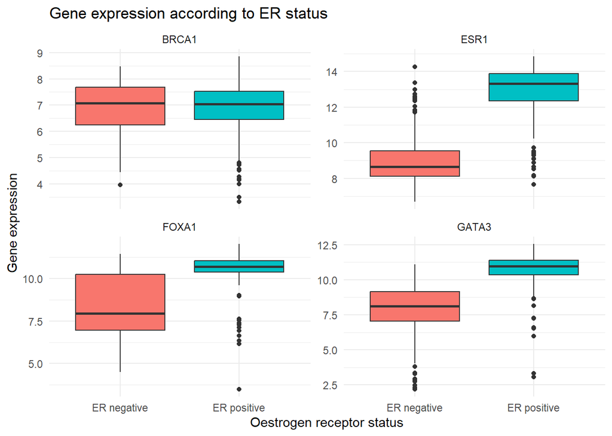

```r
# Genes to display
selected_genes <- c("BRCA1", "ESR1", "GATA3", "FOXA1")

# Add probe identifiers and calculate their variability
probe_info <- features |>
  mutate(Probe = rownames(features),variance = apply(eValues, 1, var)) |>
  filter(Gene.symbol %in% selected_genes)

# Select the most variable probe for each gene
selected_probes <- probe_info |>
  group_by(Gene.symbol) |>
  slice_max(variance, n = 1, with_ties = FALSE) |>
  ungroup()

# Create a table in long format
expression_long <- eValues[selected_probes$Probe, ] |>
  as.data.frame() |>
  rownames_to_column("Probe") |>
  pivot_longer(
    cols = -Probe,
    names_to = "Sample",
    values_to = "Expression"
  ) |>
  left_join(selected_probes |> select(Probe, Gene.symbol),by = "Probe"
  ) |>
  mutate(ER_status = rep(er_status, times = nrow(selected_probes))
  )

# Create the boxplots
ggplot(expression_long,
       aes(x = ER_status, y = Expression, fill = ER_status)) + geom_boxplot() +
  facet_wrap( ~ Gene.symbol, scales = "free_y") + labs(title =
"Gene expression according to ER status", x = "Oestrogen receptor status", y =
  "Gene expression") + theme_minimal() +  theme(legend.position = "none")
```

# 5. Results and discussions

Comment on the rationale of boxplots in 4). Discuss the it within the context of the original outcomes described in Wang et al. (2005), Minn et al. (2007). [2/10]

The boxplots allow the distribution, median and variability of gene expression to be compared between ER-negative and ER-positive tumours. ESR1 shows the clearest difference, with substantially higher expression in ER-positive tumours. FOXA1 and GATA3 also show higher expression and less variability in the ER-positive group. In contrast, BRCA1 presents very similar expression levels in both groups, with strongly overlapping distributions.

These results are consistent with Wang et al. (2005), who showed that ER-positive and ER-negative breast tumours have different gene-expression profiles and proposed separate prognostic signatures for both groups. The higher expression of ESR1, FOXA1 and GATA3 in ER-positive tumours is biologically coherent because these genes are associated with oestrogen-receptor activity. Minn et al. (2007) also showed that breast-cancer progression and metastasis involve combinations of gene-expression changes rather than the effect of a single gene. Therefore, these boxplots illustrate relevant differences according to ER status, but the statistical significance should be confirmed using the t-test and FDR-adjusted p-values.

# 6. References

Wang, Y., Klijn, J. G. M., Zhang, Y., et al. (2005). Gene-expression profiles to predict distant metastasis of lymph-node-negative primary breast cancer. The Lancet, 365, 671–679. DOI: 10.1016/S0140-6736(05)17947-1.

Minn, A. J., Gupta, G. P., Padua, D., et al. (2007). Lung metastasis genes couple breast tumor size and metastatic spread. Proceedings of the National Academy of Sciences of the United States of America, 104, 6740–6745. DOI: 10.1073/pnas.0701138104.

# Submission Checklist

- `.Rmd` knits to HTML without errors
- All required packages are loaded.
- The vdx dataset is correctly loaded and explored.
- Gene expression is compared between ER-positive and ER-negative tumours.
- The p-value histogram is included and discussed.
- FDR-adjusted p-values are calculated using the Benjamini-Hochberg method.
- Boxplots for BRCA1, ESR1, GATA3 and FOXA1 are included.
- The boxplot results are interpreted and discussed in relation to Wang et al. (2005) and Minn et al. (2007).
- All questions and reflection sections are answered.
- All code chunks completed and commented
- All reflection questions answered